# 5. Dimensionality reduction techniques

## 1. The human dataset

```r
# load the data
human <- read.csv("data/human.csv")

# add countries as rownames
rownames(human) <- human$X

# explore the dataset
str(human)
```

```
## 'data.frame':    155 obs. of  9 variables:
##  $ X                 : Factor w/ 155 levels "Afghanistan",..: 105 6 134 41 101 54 67 149 28 102 ...
##  $ edu2_ratio        : num  1.007 0.997 0.983 0.989 0.969 ...
##  $ labour_ratio      : num  0.891 0.819 0.825 0.884 0.829 ...
##  $ life_exp          : num  81.6 82.4 83 80.2 81.6 80.9 80.9 79.1 82 81.8 ...
##  $ edu_exp           : num  17.5 20.2 15.8 18.7 17.9 16.5 18.6 16.5 15.9 19.2 ...
##  $ GNI               : int  64992 42261 56431 44025 45435 43919 39568 52947 42155 32689 ...
##  $ maternal_mortality: int  4 6 6 5 6 7 9 28 11 8 ...
##  $ adolescent_birth  : num  7.8 12.1 1.9 5.1 6.2 3.8 8.2 31 14.5 25.3 ...
##  $ parliament_repr   : num  39.6 30.5 28.5 38 36.9 36.9 19.9 19.4 28.2 31.4 ...
```

```r
dim(human)
```

```
## [1] 155   9
```

The human dataset includes data from 155 countries on human development and gender inequality from the human development reports from the United Nations. Variables describing human development are life expectancy at birth (life_exp), expected years of schooling (edu_exp) and gross national income per capita (GNI). Gender inequality is described by the ratio between women and men with at least secondary education (edu2_ratio), the ratio between female and male particiation rates in the labour force (labour_ratio), the maternal mortality ratio (maternal_mortality), the birth rate among adolescents (adolescent_birth) and percentage of female representation in parliament (parliament_repr).

## 2. Exploring the human data set

```r
library(GGally)
library(dplyr)
```

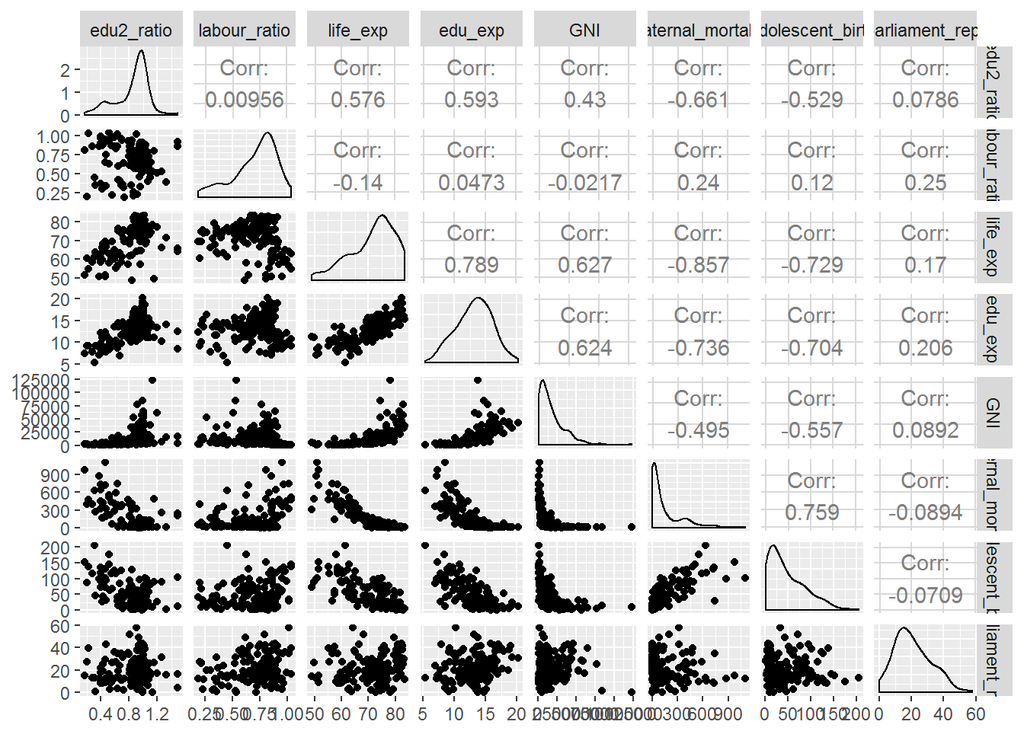

```r
human_ <- select(human, -X)

# visualize the variables
ggpairs(human_)
```

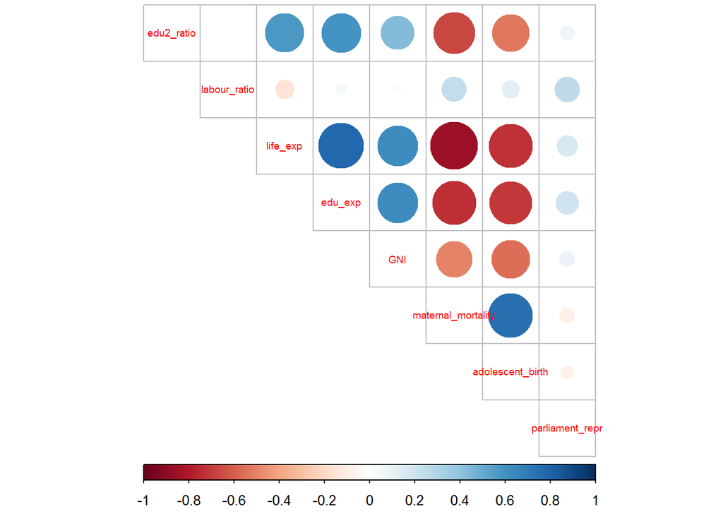

```r
library(corrplot)

cor_matrix<-cor(human_)
corrplot(cor_matrix, method="circle", type = "upper", cl.pos = "b", tl.pos = "d", tl.cex = 0.6)
```

```r
summary(human_)
```

```
##    edu2_ratio      labour_ratio       life_exp        edu_exp
##  Min.   :0.1717   Min.   :0.1857   Min.   :49.00   Min.   : 5.40
##  1st Qu.:0.7264   1st Qu.:0.5984   1st Qu.:66.30   1st Qu.:11.25
##  Median :0.9375   Median :0.7535   Median :74.20   Median :13.50
##  Mean   :0.8529   Mean   :0.7074   Mean   :71.65   Mean   :13.18
##  3rd Qu.:0.9968   3rd Qu.:0.8535   3rd Qu.:77.25   3rd Qu.:15.20
##  Max.   :1.4967   Max.   :1.0380   Max.   :83.50   Max.   :20.20
##       GNI         maternal_mortality adolescent_birth parliament_repr
##  Min.   :   581   Min.   :   1.0     Min.   :  0.60   Min.   : 0.00
##  1st Qu.:  4198   1st Qu.:  11.5     1st Qu.: 12.65   1st Qu.:12.40
##  Median : 12040   Median :  49.0     Median : 33.60   Median :19.30
##  Mean   : 17628   Mean   : 149.1     Mean   : 47.16   Mean   :20.91
##  3rd Qu.: 24512   3rd Qu.: 190.0     3rd Qu.: 71.95   3rd Qu.:27.95
##  Max.   :123124   Max.   :1100.0     Max.   :204.80   Max.   :57.50
```

For the ratio between women and men with at least secondary education (edu2_ratio), half of the countries have ratios between 0.73 and 1, very few countries have more women than men with at least secondary education.

The ratio between female and male particiation rates in the labour force (labour_ratio) is between 0.60 and 0.85 in 50% of the countries. There are only four countries where more women than men are participating in the labour force.

The life expectancy at birth (life_exp) varies a lot between countries, from a minimal of 49 to a maximum of 83.5. In 50% of countries, life expentancy is between 66 and 77.

The expected years of schooling (edu_exp) is normally distributed. There is huge variation between countries, varying between a minimal of 5 to a maximum of 20 years of education.

Maternal mortality ratio is below 200 for most countries, but there are a few countries for which the maternal mortality ratio is fairly high.

Most countrie shave adolescent birth rate below 50

The representation of women in parliament is only 20% in most countries. Only 2 countries have representation of higher than 50%.

There are strong positive correlations between life expectancy and expected years of schooling. As life is longer, people spend more time at school. The maternal mortality rate and adolescent birth rate have strong positive correlation. There is a strong negative correlation between life expectany and maternal mortality rate. Both variables describe the quality of health care in a country. Consequently, life expectancy and expected years of schooling both have strong negative correlation with maternal mortality rate and adolescent birth rate.